# feather river redd data exploration

2024-08-27

Goal of this document is to review the Feather River redd data and understand the following:

- what data are collected?
- what is the quality of the data?
- what are the data limitations?
- how are these data useful to Science Plan hypotheses?

Combining all years into one object

```
## Rows: 29,626
## Columns: 21
## $ date            <dttm> 2014-09-09, 2014-09-09, 2014-09-15, 2014-09-15, 2014-…
## $ survey_wk       <chr> "1-1", "1-1", "2-1", "2-1", "2-1", "2-1", "2-1", "2-1"…
## $ location        <chr> "Moe's Side Channel", "Upper Cottonwood", "Cottonwood"…
## $ file_number     <dbl> 1, 2, 1, 2, 3, 4, 5, 6, 7, 8, 9, 10, 11, 12, 13, 14, 1…
## $ type            <chr> "p", "p", "p", "p", "p", "p", "p", "p", "p", "p", "p",…
## $ number_of_redds <dbl> 0, 1, 1, 1, 1, 1, 1, 1, 1, 1, 1, 1, 1, 1, 1, 1, 1, 1, …
## $ number_salmon   <dbl> 1, 1, 1, 0, 3, 0, 0, 0, 0, 0, 0, 1, 0, 0, 0, 0, 0, 1, …
## $ latitude_m_n    <dbl> 4375043, 4375121, 4375108, 4375106, 4375110, 4375113, …
## $ longitude_m_e   <dbl> 6239424.4, 624284.0, 624147.7, 624150.0, 624158.1, 624…
## $ depth_m         <dbl> 0.30, 0.62, NA, NA, NA, NA, NA, NA, NA, NA, NA, 0.72, …
## $ pot_depth_m     <dbl> 0.50, 0.70, NA, NA, NA, NA, NA, NA, NA, NA, NA, 0.76, …
## $ velocity_m_s    <dbl> 0.61, 0.89, NA, NA, NA, NA, NA, NA, NA, NA, NA, 0.55, …
## $ percent_fines   <dbl> 40, 0, NA, NA, NA, NA, NA, NA, NA, NA, NA, 0, 0, 0, 0,…
## $ percent_small   <dbl> 20, 65, NA, NA, NA, NA, NA, NA, NA, NA, NA, 40, 40, 60…
## $ percent_med     <dbl> 35, 30, NA, NA, NA, NA, NA, NA, NA, NA, NA, 50, 60, 20…
## $ percent_large   <dbl> 5, 5, NA, NA, NA, NA, NA, NA, NA, NA, NA, 10, 0, 10, 0…
## $ percent_boulder <dbl> 0, 0, NA, NA, NA, NA, NA, NA, NA, NA, NA, 0, 0, 10, 0,…
## $ redd_width_m    <dbl> 1.1, 2.5, NA, NA, NA, NA, NA, NA, NA, NA, NA, 1.5, 2.0…
## $ redd_length_m   <dbl> 2.0, 3.5, NA, NA, NA, NA, NA, NA, NA, NA, NA, 2.0, 2.5…
## $ number_redds    <dbl> NA, NA, NA, NA, NA, NA, NA, NA, NA, NA, NA, NA, NA, NA…
## $ longitude_n_e   <dbl> NA, NA, NA, NA, NA, NA, NA, NA, NA, NA, NA, NA, NA, NA…
```

```
## tibble [29,626 × 21] (S3: tbl_df/tbl/data.frame)
##  $ date           : POSIXct[1:29626], format: "2014-09-09" "2014-09-09" ...
##  $ survey_wk      : chr [1:29626] "1-1" "1-1" "2-1" "2-1" ...
##  $ location       : chr [1:29626] "Moe's Side Channel" "Upper Cottonwood" "Cottonwood" "Cottonwood" ...
##  $ file_number    : num [1:29626] 1 2 1 2 3 4 5 6 7 8 ...
##  $ type           : chr [1:29626] "p" "p" "p" "p" ...
##  $ number_of_redds: num [1:29626] 0 1 1 1 1 1 1 1 1 1 ...
##  $ number_salmon  : num [1:29626] 1 1 1 0 3 0 0 0 0 0 ...
##  $ latitude_m_n   : num [1:29626] 4375043 4375121 4375108 4375106 4375110 ...
##  $ longitude_m_e  : num [1:29626] 6239424 624284 624148 624150 624158 ...
##  $ depth_m        : num [1:29626] 0.3 0.62 NA NA NA NA NA NA NA NA ...
##  $ pot_depth_m    : num [1:29626] 0.5 0.7 NA NA NA NA NA NA NA NA ...
##  $ velocity_m_s   : num [1:29626] 0.61 0.89 NA NA NA NA NA NA NA NA ...
##  $ percent_fines  : num [1:29626] 40 0 NA NA NA NA NA NA NA NA ...
##  $ percent_small  : num [1:29626] 20 65 NA NA NA NA NA NA NA NA ...
##  $ percent_med    : num [1:29626] 35 30 NA NA NA NA NA NA NA NA ...
##  $ percent_large  : num [1:29626] 5 5 NA NA NA NA NA NA NA NA ...
##  $ percent_boulder: num [1:29626] 0 0 NA NA NA NA NA NA NA NA ...
##  $ redd_width_m   : num [1:29626] 1.1 2.5 NA NA NA NA NA NA NA NA ...
##  $ redd_length_m  : num [1:29626] 2 3.5 NA NA NA NA NA NA NA NA ...
##  $ number_redds   : num [1:29626] NA NA NA NA NA NA NA NA NA NA ...
##  $ longitude_n_e  : num [1:29626] NA NA NA NA NA NA NA NA NA NA ...
```

### Data exploration

Exploring fields that have data consistently

#### date

```
## [1] "2014-09-09 UTC" "2022-12-02 UTC"
```

#### location

- Location clean up is needed. There are some names that appear less than 5 times. We could check if they correspond to another location name, and it is spelled differently

```
##
##                         Aleck                  Aleck Riffle
##                            90                            32
##                       Bedrock                Bedrock Riffle
##                           898                           263
##           Below Big hole East           Below Big Hole East
##                             1                            20
##        Below Lower Auditorium                       Big Bar
##                           414                            33
##                 Big Hole East                 Big Hole West
##                           181                            23
##                    Big Riffle                    Cottonwood
##                            70                           868
##                    Developing             Developing Riffle
##                             4                             3
##                           Eye              Eye Side Channel
##                            42                           107
## G-95 East Side Channel Bottom                 G-95 East Top
##                             1                             1
##                     G-95 Main G-95 West Side Channel Bottom
##                             1                             1
##               G95 East Bottom  G95 East Side Channel Bottom
##                            68                            66
##     G95 East side Channel Top     G95 East Side Channel Top
##                             4                            30
##                  G95 East Top                      G95 Main
##                            71                            59
##                      G95 West               G95 West Bottom
##                            14                             1
##         G95 West Side Channel                       Gateway
##                            23                            42
##          Gateway Main Channel          Gateway Side Channel
##                            15                             8
##                         Goose                  Goose Riffle
##                            22                             7
##                 Great Western                      Hatchery
##                             7                          1594
##                 Hatchery Pipe               Hatchery Riffle
##                           670                          1264
##         Hatchery Side Channel                     High Flow
```

[output cut: 30 more lines]

```
##                          2037                             2
##              Upper Cottonwood                Upper Hatchery
##                           484                           696
##         Upper Hatchery Riffle                    Upper Hour
##                           691                            62
##               Upper Hour east                 Upper Mathews
##                             2                           126
##                Upper Matthews               Upper Mcfarland
##                            33                             2
##               Upper McFarland                Upper Robinson
##                            13                           843
##                    Vance East                    Vance West
##                           145                            32
##                          Weir                   Weir Riffle
##                           105                            70
```

**Locations surveyed less than 5 times**

For locations that are being surveyed less than five times, we might want to verify if they belong to other location area names. Otherwise, these sites might not have enough data to reliably analyze over time.

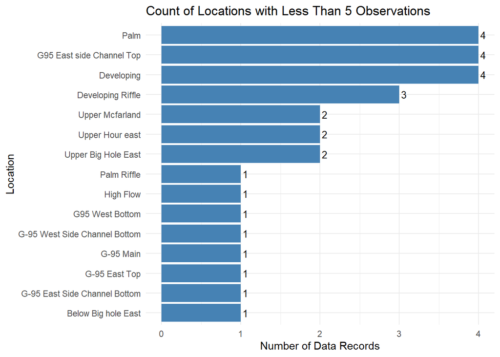

**Frequent locations and years surveyed**

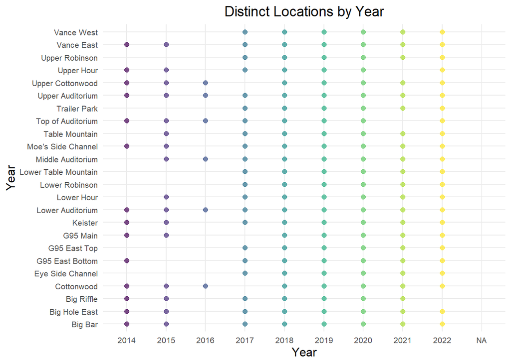

#### type

- note that there is one type record that is 3761, with no date associated, is this an error?

**Observations by type and date**

```
## [1] "p"    "a"    NA     "P"    "3761"
```

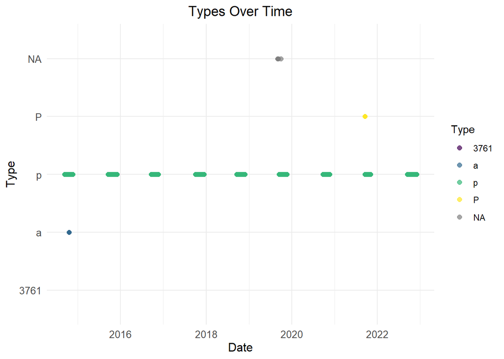

**Count of observations by type**

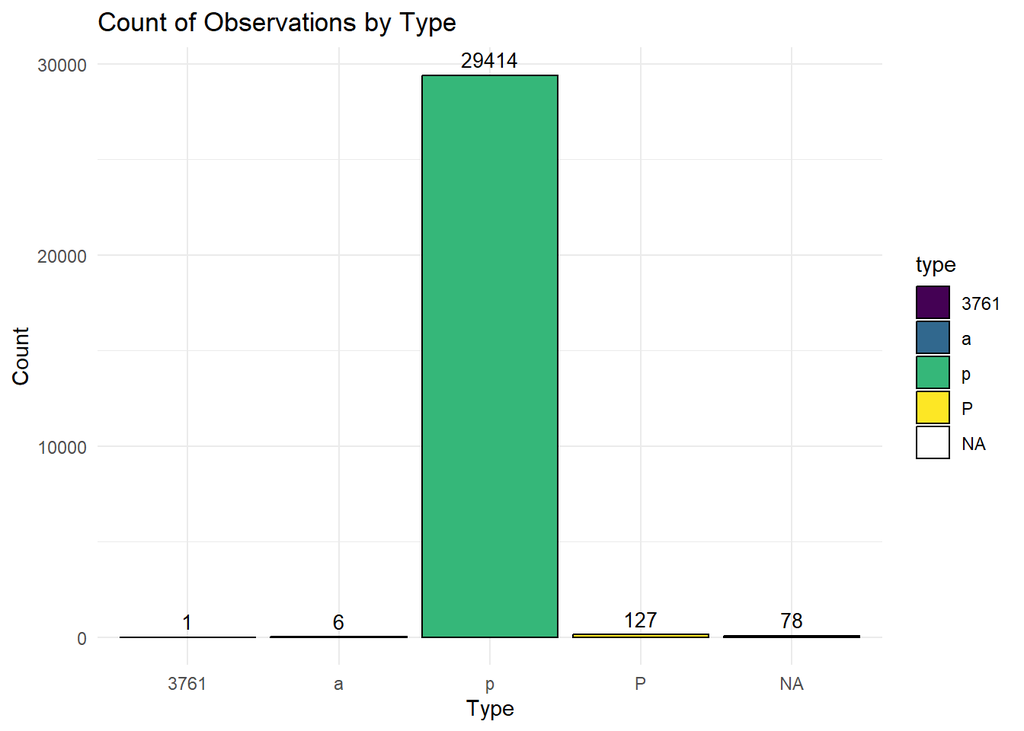

#### redd_count

```
## [1]    0 2361
```

#### salmon_count

**Salmon counts by year**

```
## [1]    0 1705
```

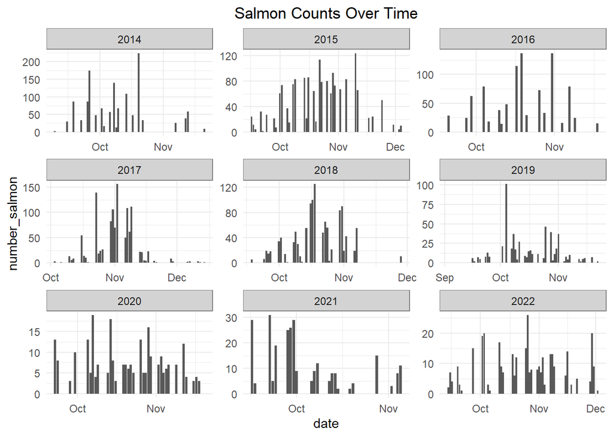

Latitude and longitude needs to be transformed to UTM #TODO